# TP3

Louai KASSA BAGHDOUCHE

23/11/2020

# 1. PARTIE 1

1. on importe la table dans le fichier IMCenfants

```r
tab = read.table(file.choose(), header=TRUE, sep="\t", dec=",")
tab
```

```
##     SEXE zep poids an mois taille
## 1      F   O  16.0  3    5  100.0
## 2      F   O  14.0  3   10   97.0
## 3      G   O  13.5  3    5   95.5
## 4      F   O  15.4  4    0  101.0
## 5      G   N  16.5  3    8  100.0
## 6      G   O  16.0  4    0   98.5
## 7      G   N  17.0  3   11  103.0
## 8      G   O  14.8  3    9   98.0
## 9      G   O  17.0  4    1  101.5
## 10     G   O  16.7  3    3  100.0
## 11     G   O  15.5  3    7   98.5
## 12     G   O  15.0  3    9  101.0
## 13     G   O  14.5  3    9   94.0
## 14     F   N  16.8  4    0  103.0
```

[output cut: 138 more lines]

2. on trace l’histogramme d’effectif des tailles

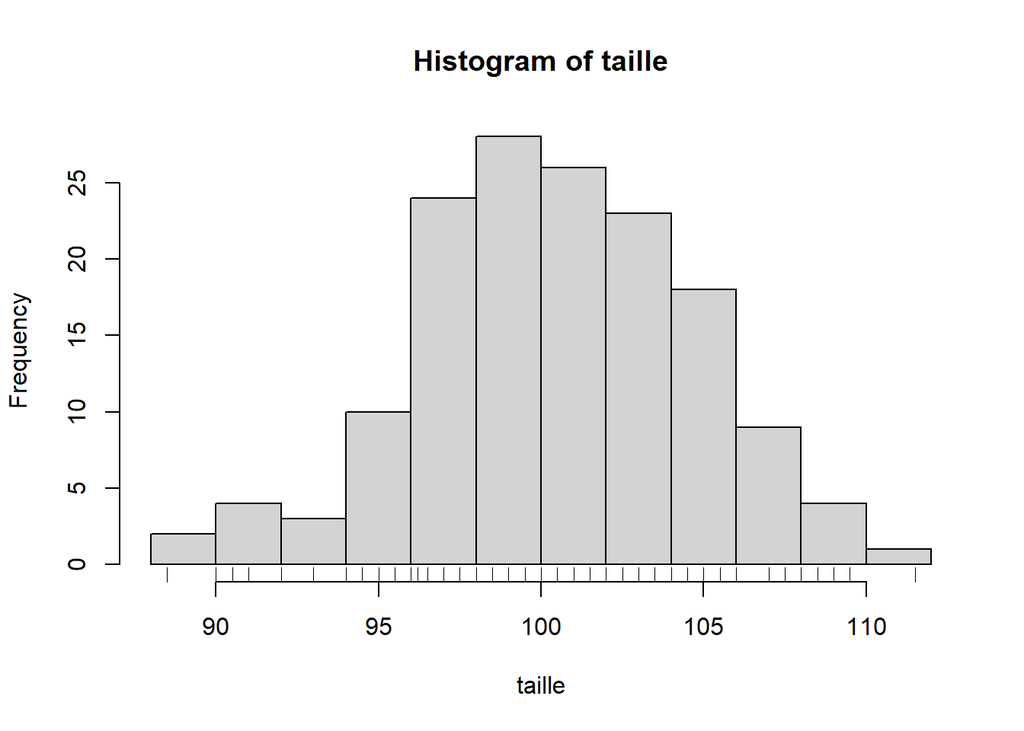

```r
taille = tab$taille
hist(taille, breaks=c(88, 90, 92, 94, 96, 98, 100, 102, 104, 106, 108, 110, 112), freq=TRUE)
rug(taille)
```

3. On trace l’histogramme de fréquence

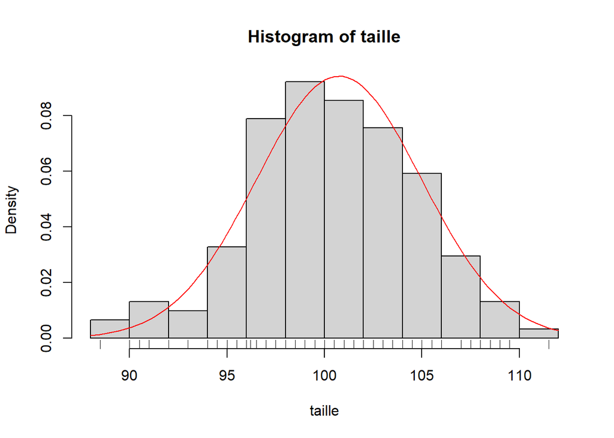

```r
hist(taille, breaks=c(88, 90, 92, 94, 96, 98, 100, 102, 104, 106, 108, 110, 112), freq=FALSE)
rug(taille)
curve(dnorm(x, mean(taille), sd(taille)), add=TRUE, col='red')
```

4.

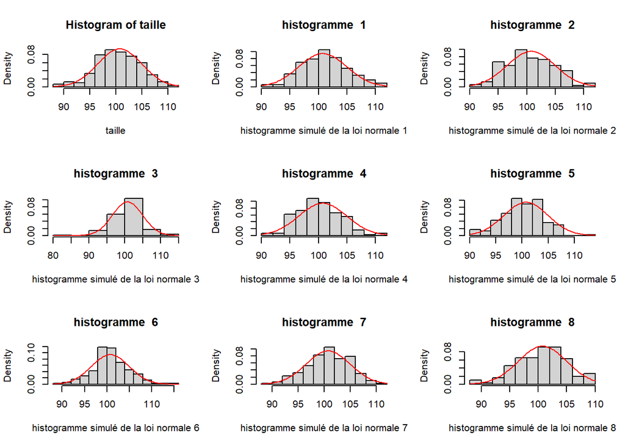

```r
par(mfrow=c(3,3))
hist(taille, freq=FALSE)
curve(dnorm(x, mean(taille), sd(taille)), add=TRUE, col='red')
for (i in 1:8) {
  hist(rnorm(length(taille), mean(taille), sd(taille)), main = paste('histogramme ',i), xlab=paste('histogramme simulé de la loi normale', i), freq=FALSE)
  curve(dnorm(x, mean(taille), sd(taille)), add=TRUE, col='red')
}
```

8. Refaire les questions 1->4 en remplaçant « normale » par d’autres lois, mais avec seulement 4 graphiques en tout. par (mfrow=c(2,2)

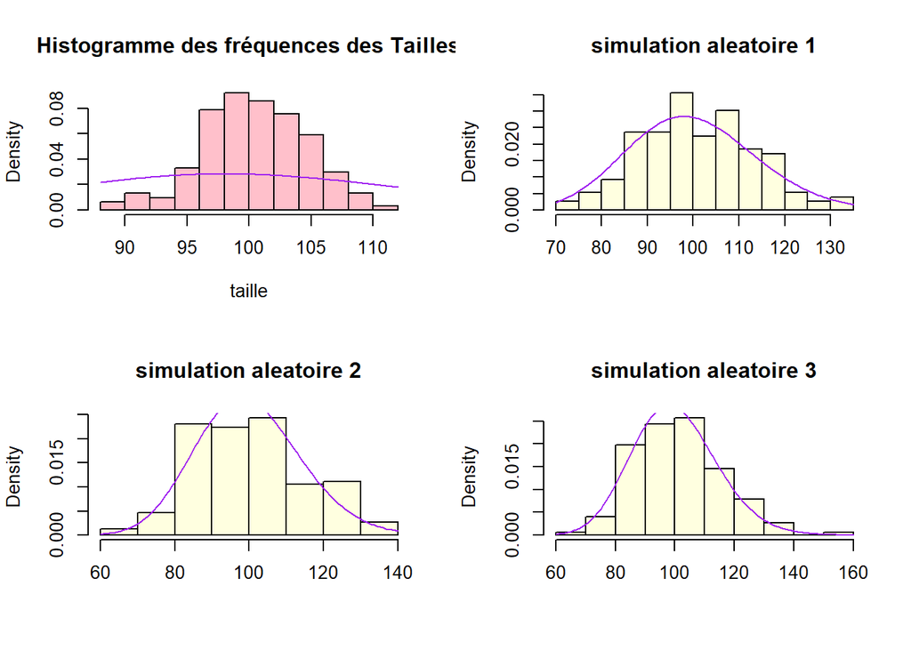

```r
par(mfrow=c(2,2))
hist(taille, main="Histogramme des fréquences des Tailles", freq = FALSE, col = 'Pink')

#Loi du khi-carré dchisq(x, k= dl)
curve(dchisq(x, 100), add=TRUE, col="Purple")
for (i in 1:3){
  hist(rchisq(length(taille), 100), freq = FALSE, main = paste("simulation aleatoire", i), col = 'lightYellow', xlab = NULL)
  curve(dchisq(x, 100), add=TRUE, col="Purple")
}
```

10. Remplacer l’histogramme par un autre graphique : boxplot(), qqplot(), qqnorm et qqline().

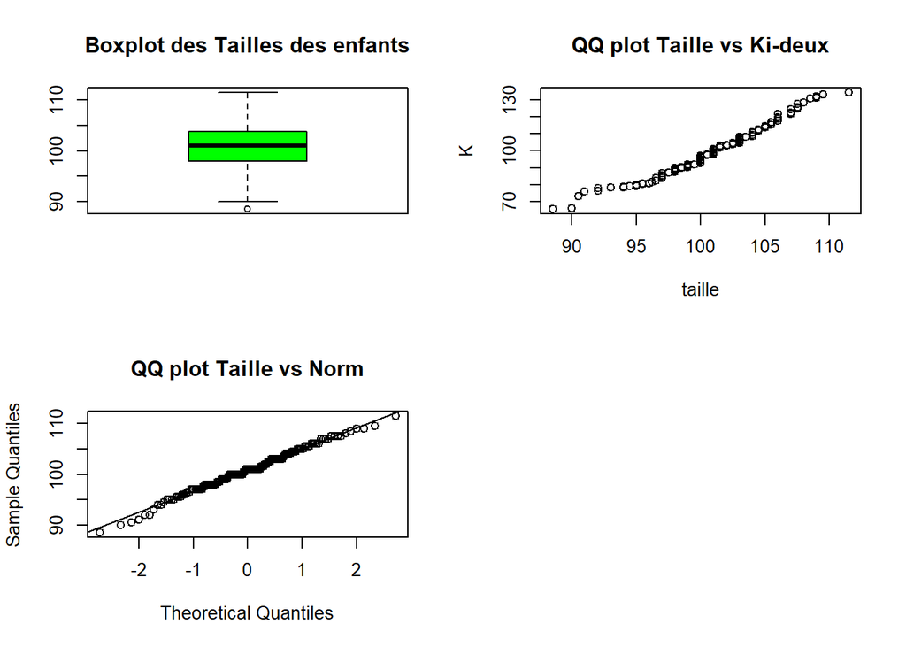

```r
par(mfrow=c(2,2))
boxplot(taille, col="Green", main="Boxplot des Tailles des enfants")
K = (rchisq(length(taille), 100))
qqplot(taille, K, main="QQ plot Taille vs Ki-deux")
qqnorm(taille, main="QQ plot Taille vs Norm")
qqline(taille, main="QQ line Taille")
```

11. Revenir à un graphique par fenêtre avec la commande par(mfrow=c(1,1))

```r
mfrow=c(1,1)
```

12. Calculer moyenne, variance, deciles, de la variable taille.

```r
mean(taille) #Calcul de moyenne
```

```
## [1] 100.748
```

```r
var(taille) #Calcul de variance
```

```
## [1] 17.93139
```

```r
quantile(taille,seq(0,1,by=0.1),type=1) # Calcul de déciles
```

```
##    0%   10%   20%   30%   40%   50%   60%   70%   80%   90%  100%
##  88.5  95.5  97.0  98.5 100.0 101.0 101.5 103.0 104.5 106.0 111.5
```

# PARTIE 2: Analyse des données

#### 1. Importation du fichier de jeux de données jeu3.txt

```r
tabjeu3 = read.table(file.choose(), header=TRUE, sep='\t', dec=',')
tabjeu3
```

```
##     sexe situation the cafe taille poids age viande poisson fruit_crus
## 1      2         1   0    0    151    58  72      4       3          1
## 2      2         1   1    1    162    60  68      5       2          5
## 3      2         1   0    4    162    75  78      3       1          5
## 4      2         1   0    0    154    45  91      0       4          4
## 5      2         1   2    1    154    50  65      5       3          5
## 6      2         1   2    0    159    66  82      4       2          5
## 7      2         1   2    0    160    66  74      3       3          5
## 8      2         1   0    2    163    66  73      4       2          5
## 9      2         1   0    3    154    60  89      4       3          5
## 10     2         1   0    2    160    77  87      2       3          5
## 11     2         1   0    2    175    68  91      5       2          5
## 12     2         1   2    0    165    75  81      5       2          2
## 13     2         1   0    3    158    53  89      4       2          5
## 14     2         1   2    0    155    63  79      3       1          5
```

[output cut: 439 more lines]

La liste des variables de ce jeu de données

```r
names(tabjeu3)
```

```
##  [1] "sexe"               "situation"          "the"
##  [4] "cafe"               "taille"             "poids"
##  [7] "age"                "viande"             "poisson"
## [10] "fruit_crus"         "fruit_legume_cuits" "chocol"
## [13] "matgras"
```

#### 2. le mode des variables

```r
# création d'une fonction qui calcule le mode
getmode <- function(v) {
    uniqv = unique(v)
    uniqv[which.max(tabulate(match(v, uniqv)))]
}
# mode de la variable situation
print(getmode(tabjeu3$situation))
```

```
## [1] 2
```

```r
# mode de la varaible taille
print(getmode(tabjeu3$taille))
```

```
## [1] 160
```

```r
# mode ded la variable chocol
print(getmode(tabjeu3$chocol))
```

```
## [1] 5
```

#### 3. le choix des classes pour la variable taille

```r
# on va diviser les taille selon 4 classes;
classDesTailles = cut(tab_jeu3$taille, 4)
a = table(classDesTailles)
a[a == max(a)]
```

```
## (152,164]
##       110
```

```r
# maintenant on trouve la classe moodale
sort(table(classDesTailles), decreasing=TRUE)[1]
```

```
## (152,164]
##       110
```

#### 4. le calcul de la médiane

```r
# la médiane de la variable situation
median(tabjeu3$situation)
```

```
## [1] 2
```

```r
# la médiane de la variable chocol
median(tabjeu3$chocol)
```

```
## [1] 2
```

#### 5. le tri à plat

```r
# tri à plat de la variable chocol
plat.chocolat = table(tabjeu3$chocol); plat.chocolat
```

```
##
##  0  1  2  3  4  5
## 50 62 16 22 11 65
```

```r
# tri à plat de de la variable fruits_crus
plat.fruit = table(tabjeu3$fruit_crus); plat.fruit
```

```
##
##   0   1   2   3   4   5
##   2   8   8  14  22 172
```

```r
index = sum(plat.chocolat/2)
sorted = sort(tabjeu3$taille); sorted[index]
```

```
## [1] 163
```

```r
index = sum(plat.fruit/2)
sorted = sort(tabjeu3$fruit_crus); sorted[index]
```

```
## [1] 5
```

#### 7. le calcul des quartiles

```r
quantile(table(classDesTailles), na.rm=T,type=1)
```

```
##   0%  25%  50%  75% 100%
##   17   17   20   79  110
```

#### 8. la polygone des fréquences cumulées

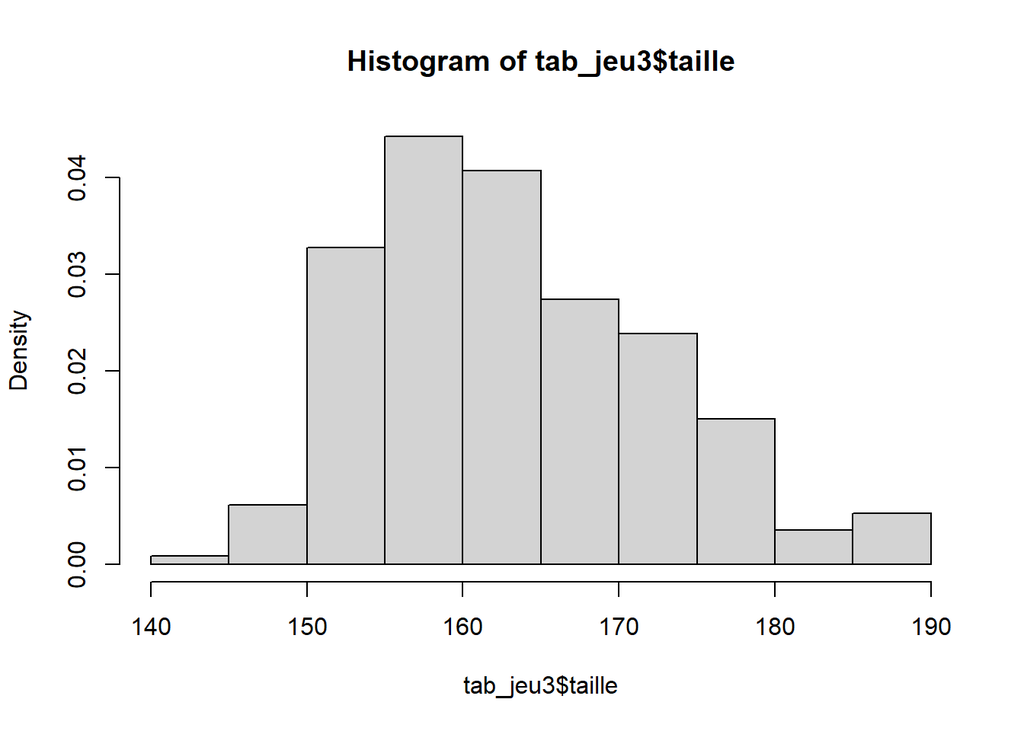

```r
histo = hist(tab_jeu3$taille, freq=FALSE)
```

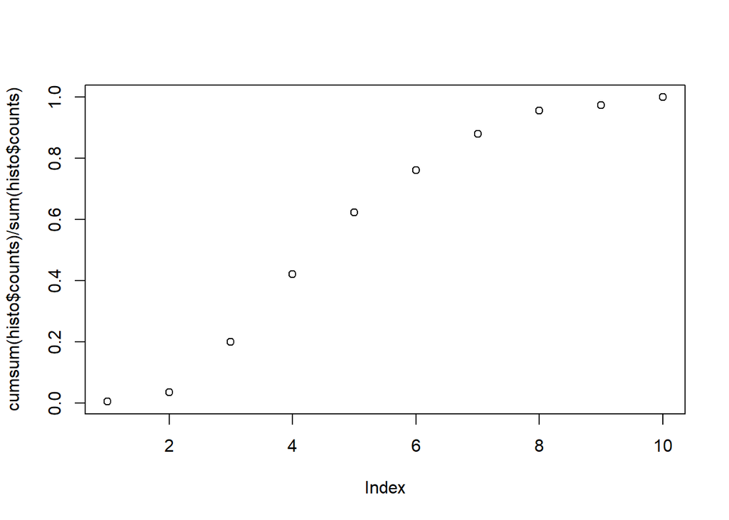

```r
plot(cumsum(histo$counts)/sum(histo$counts))
```

#### 9. le calcul de la moyenne des variables

```r
# la moyenne de la variable situation
mean(tabjeu3$situation)
```

```
## [1] 1.606195
```

```r
# la moyenne de la variable chocol
mean(tabjeu3$chocol)
```

```
## [1] 2.340708
```

```r
# la moyenne de la varaible taille
mean(tabjeu3$taille)
```

```
## [1] 163.9602
```

## PARTIE 3 . Analyse de données

1. A l’aide de la fonction str, préciser le type de variables présent dans ce jeu de données. A l’aide de la page d’aide de mtcars, préciser s’il s’agit de variables numériques qualitatives, qualitatives ordonnées, quantitatives discrètes, ou quantitatives continues.

```r
library(datasets);data(mtcars);
str(mtcars)
```

```
## 'data.frame':    32 obs. of  11 variables:
##  $ mpg : num  21 21 22.8 21.4 18.7 18.1 14.3 24.4 22.8 19.2 ...
##  $ cyl : num  6 6 4 6 8 6 8 4 4 6 ...
##  $ disp: num  160 160 108 258 360 ...
##  $ hp  : num  110 110 93 110 175 105 245 62 95 123 ...
##  $ drat: num  3.9 3.9 3.85 3.08 3.15 2.76 3.21 3.69 3.92 3.92 ...
##  $ wt  : num  2.62 2.88 2.32 3.21 3.44 ...
##  $ qsec: num  16.5 17 18.6 19.4 17 ...
##  $ vs  : num  0 0 1 1 0 1 0 1 1 1 ...
##  $ am  : num  1 1 1 0 0 0 0 0 0 0 ...
##  $ gear: num  4 4 4 3 3 3 3 4 4 4 ...
##  $ carb: num  4 4 1 1 2 1 4 2 2 4 ...
```

Nous trouvons 11 variables numériques répertoriant des aspects des 32 automobiles comparées, nous allons trier les variables en trois groupes selon leur type : - variables qualitatives (non-ordonnées) : vs, am - variables quantitatives discrètes : cyl, gear, carb - variables quantitatives continues : mpg, disp, drat, wt, qsec

2. Vous trouverez dans la page d’aide de mtcars dans l’onglet « exemples », le script suivant : mtcars2 <- within(mtcars, { vs <- factor(vs, labels = c(“V”, “S”)) am <- factor(am, labels = c(“automatic”, “manual”)) cyl <- ordered(cyl) gear <- ordered(gear) carb <- ordered(carb) })

Effectuer un summary(mtcars) ; summary(mtcars2)

```r
mtcars2 <- within(mtcars, {
   vs <- factor(vs, labels = c("V", "S"))
   am <- factor(am, labels = c("automatic", "manual"))
   cyl  <- ordered(cyl)
   gear <- ordered(gear)
   carb <- ordered(carb)
})
summary(mtcars);
```

```
##       mpg             cyl             disp             hp
##  Min.   :10.40   Min.   :4.000   Min.   : 71.1   Min.   : 52.0
##  1st Qu.:15.43   1st Qu.:4.000   1st Qu.:120.8   1st Qu.: 96.5
##  Median :19.20   Median :6.000   Median :196.3   Median :123.0
##  Mean   :20.09   Mean   :6.188   Mean   :230.7   Mean   :146.7
##  3rd Qu.:22.80   3rd Qu.:8.000   3rd Qu.:326.0   3rd Qu.:180.0
##  Max.   :33.90   Max.   :8.000   Max.   :472.0   Max.   :335.0
##       drat             wt             qsec             vs
##  Min.   :2.760   Min.   :1.513   Min.   :14.50   Min.   :0.0000
##  1st Qu.:3.080   1st Qu.:2.581   1st Qu.:16.89   1st Qu.:0.0000
##  Median :3.695   Median :3.325   Median :17.71   Median :0.0000
##  Mean   :3.597   Mean   :3.217   Mean   :17.85   Mean   :0.4375
##  3rd Qu.:3.920   3rd Qu.:3.610   3rd Qu.:18.90   3rd Qu.:1.0000
##  Max.   :4.930   Max.   :5.424   Max.   :22.90   Max.   :1.0000
##        am              gear            carb
##  Min.   :0.0000   Min.   :3.000   Min.   :1.000
##  1st Qu.:0.0000   1st Qu.:3.000   1st Qu.:2.000
##  Median :0.0000   Median :4.000   Median :2.000
##  Mean   :0.4062   Mean   :3.688   Mean   :2.812
##  3rd Qu.:1.0000   3rd Qu.:4.000   3rd Qu.:4.000
##  Max.   :1.0000   Max.   :5.000   Max.   :8.000
```

```r
summary(mtcars2)
```

```
##       mpg        cyl         disp             hp             drat
##  Min.   :10.40   4:11   Min.   : 71.1   Min.   : 52.0   Min.   :2.760
##  1st Qu.:15.43   6: 7   1st Qu.:120.8   1st Qu.: 96.5   1st Qu.:3.080
##  Median :19.20   8:14   Median :196.3   Median :123.0   Median :3.695
##  Mean   :20.09          Mean   :230.7   Mean   :146.7   Mean   :3.597
##  3rd Qu.:22.80          3rd Qu.:326.0   3rd Qu.:180.0   3rd Qu.:3.920
##  Max.   :33.90          Max.   :472.0   Max.   :335.0   Max.   :4.930
##        wt             qsec       vs             am     gear   carb
##  Min.   :1.513   Min.   :14.50   V:18   automatic:19   3:15   1: 7
##  1st Qu.:2.581   1st Qu.:16.89   S:14   manual   :13   4:12   2:10
##  Median :3.325   Median :17.71                         5: 5   3: 3
##  Mean   :3.217   Mean   :17.85                                4:10
##  3rd Qu.:3.610   3rd Qu.:18.90                                6: 1
##  Max.   :5.424   Max.   :22.90                                8: 1
```

Comparez les résultats obtenus. Qu’est-ce qui vous parait le plus adapté ? Les résultats obtenus par summary(mtcars2) semblent plus adaptés pour des statistiques car les variables qualitatives sont dénombrées selon leur qualité et les variables quantitatives discrètes sont ordonnées en fonction de leur quantité.

3. Effectuer des représentations graphiques univariées des différentes colonnes du dataframe mtcars ou mtcars2 en tenant compte du type de variable concerné. Familiarisez-vous avec les fonctions boxplot(), barplot(), hist(), pie(),

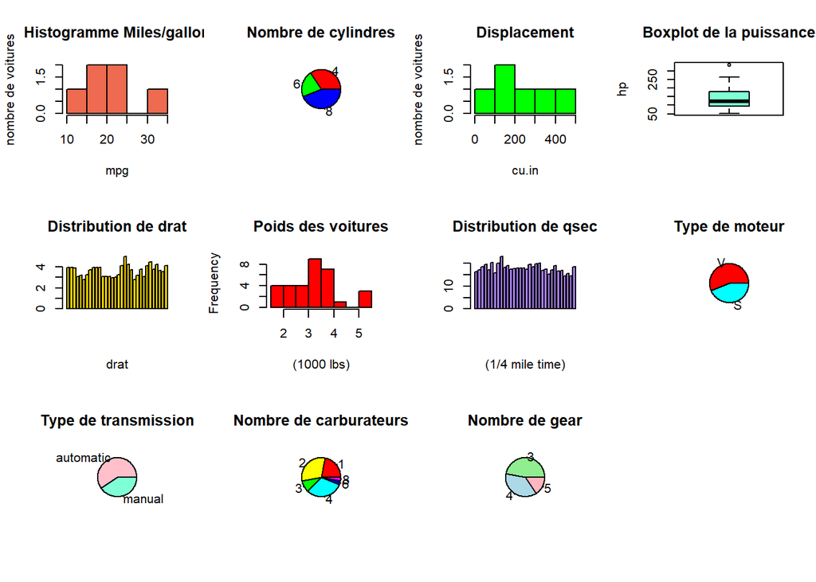

```r
par(mfrow=c(3,4))

hist(summary(mtcars2$mpg),main = "Histogramme Miles/gallon", xlab="mpg",ylab="nombre de voitures", col= "coral2")

pie(summary(mtcars2$cyl), main="Nombre de cylindres",col=rainbow(3))

hist(summary(mtcars2$disp),main = "Displacement", xlab="cu.in",ylab="nombre de voitures", col= "green")

boxplot((mtcars2$hp), main="Boxplot de la puissance",ylab="hp", col="aquamarine")

barplot(mtcars2$drat,main = "Distribution de drat", xlab="drat", col= "gold")

hist(mtcars2$wt,main = "Poids des voitures", xlab="(1000 lbs)", col= "red")

barplot(mtcars2$qsec,main = "Distribution de qsec", xlab="(1/4 mile time)", col= "mediumpurple1")

pie(summary(mtcars2$vs),main = "Type de moteur", col= rainbow(2))

pie(summary(mtcars2$am),main = "Type de transmission", col=c("pink", "aquamarine"))

pie(summary(mtcars2$carb), main="Nombre de carburateurs",col=rainbow(6))

pie(summary(mtcars2$gear), main="Nombre de gear",col=c("lightgreen","lightblue","lightpink"))
```